# Intro to R - v2

Edwin Lo

2022-02-26

```r
summary(cars)
# edit(cars)
```

We will from now on, take advantages of the display functions in the library `ezids` to make the output look nicer like this:

```r
xkablesummary(cars, title = "Cars Statistics Summary")
```

Cars Statistics Summary

|  | speed | dist |
| --- | --- | --- |
| Min | Min. : 4.0 | Min. : 2 |
| Q1 | 1st Qu.:12.0 | 1st Qu.: 26 |
| Median | Median :15.0 | Median : 36 |
| Mean | Mean :15.4 | Mean : 43 |
| Q3 | 3rd Qu.:19.0 | 3rd Qu.: 56 |
| Max | Max. :25.0 | Max. :120 |

The dataset/data frame cars is in the base library called “datasets” that comes with R. There are a lot more datasets to explore there.

Each code chunk can have R-markdown settings of `echo=FALSE`, `eval=TRUE`, `results='hide'`, `message=FALSE`, `warning=FALSE`, etc. OR just `include=FALSE` will set all those options to `FALSE` (except `eval=TRUE` is the default).

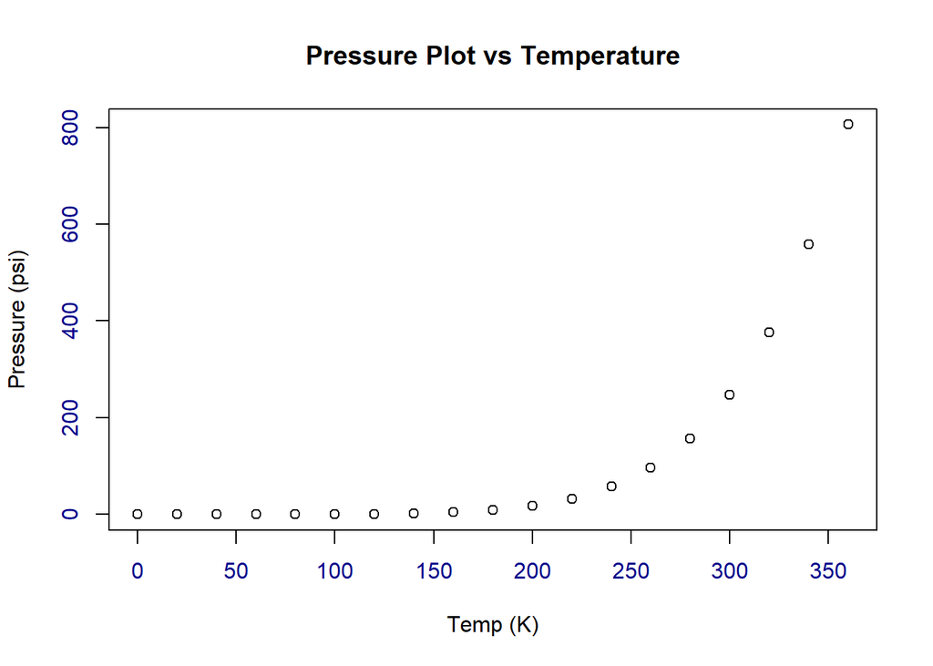

```r
summary(pressure)
plot(pressure, main = "Pressure Plot vs Temperature", xlab = "Temp (K)", ylab = "Pressure (psi)",
     col.axis = "darkblue")
```

```r
# This is just plotting the pressure
# Always include title, and best to give appropriate x/y-labels
# ALWAYS add title, and NEVER say x vs y.
```

Next, try echo=FALSE

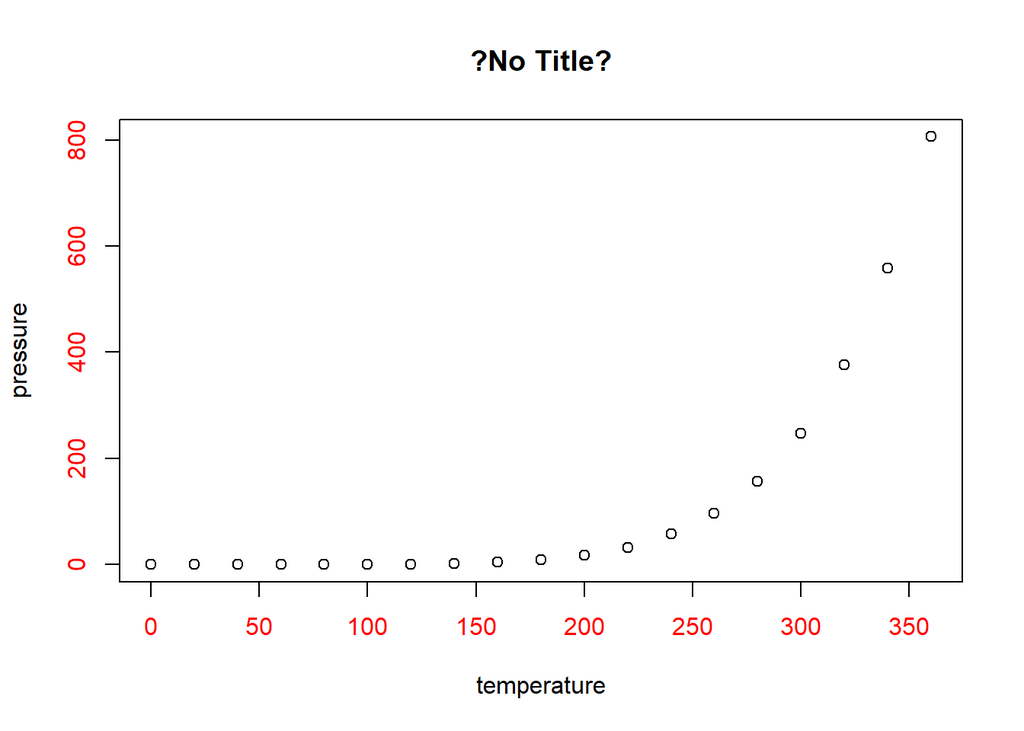

Then we try `include=FALSE`

Plot is a general function in the base library to make plots. It can make different kinds of plots, depending on the dataframe you put in.

# Biggest Header (h1): What is a package?

## Slightly Bigger Header (h2)

### Somewhat Bigger Header (h3)

#### Header line (h4, bold faced)

You can also include **in-line** R calculations like this: the average pressure is 124.337.

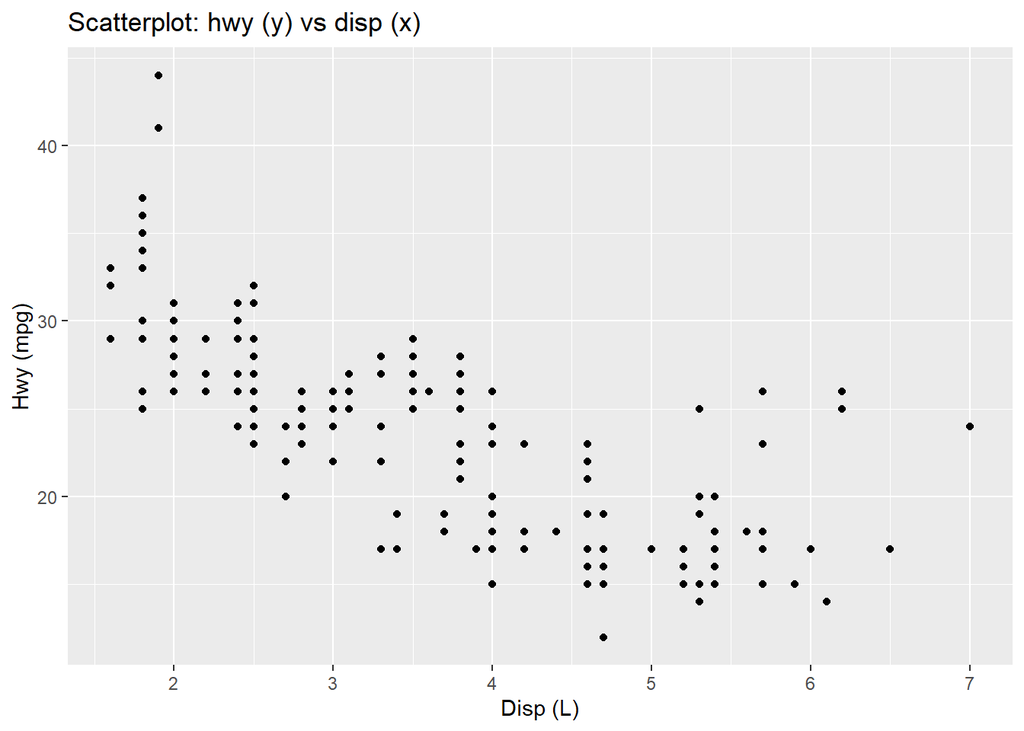

```r
loadPkg("ggplot2") # you can use library with or without double quotes. But install.packages requires double quotes.
# edit(mpg)
# ?mpg # same as help(mpg)
head(mpg)
ggplot(data=mpg)+
  geom_point(mapping = aes(x=displ, y=hwy))+
  labs(x="Disp (L)", y="Hwy (mpg)") +
  labs(title="Scatterplot: hwy (y) vs disp (x)")
```

```r
  # ALWAYS add title, and NEVER say x vs y.
# detach("package:ggplot2", unload = T) # consider detach packages no longer use to free up system memory
```

Now we can also add a color into the mix with a simple adjustment to the code

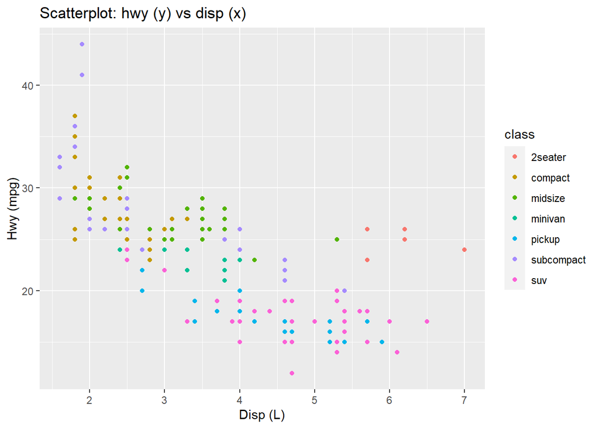

```r
ggplot(data=mpg)+
  geom_point(mapping = aes(x=displ, y=hwy, color=class)) +
  labs(x="Disp (L)", y="Hwy (mpg)") +
  labs(title="Scatterplot: hwy (y) vs disp (x)")
```

```r
# detach("package:ggplot2", unload = T) # consider detach packages no longer use to free up system memory
```

So how do we get data into R: First we have to know where R is pulling our data from, we can do this by determining the location of our current working directly

```r
getwd() # If file not in the same directory of this RMD, or the working directory (wd), you will need to setwd()
```

If you want to move your working directory you can use the `setwd("Insert File Location Here")`

```r
Admit = data.frame(read.csv("LogRegAdmit.csv"))
head(Admit)
```

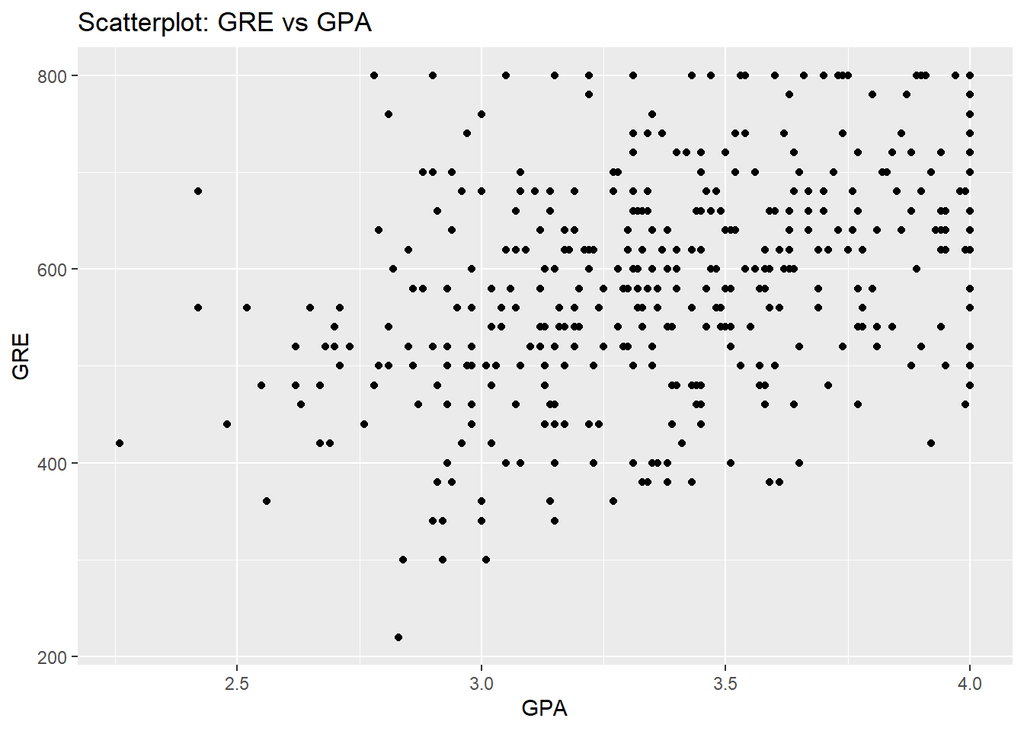

```r
# loadPkg("ggplot2")
# head(Admit)
xkabledplyhead(Admit)
# install.packages("tidyverse")
# library(tidyverse)
loadPkg("tidyverse")
glimpse(Admit)
ggplot(data=Admit)+
  geom_point(mapping = aes(x=gpa, y=gre))+
  labs(x="GPA", y="GRE") +
  labs(title="Scatterplot: GRE vs GPA")
```

```r
# detach("package:ggplot2", unload = T) # consider detach packages no longer use to free up system memory
unloadPkg("tidyverse")
```

As you might now notice, install.packages does not work well with knitr. You will need to comment out these lines before knitting. Other functions such as “View”, “edit”, which shifts the focus to another window/tab also do not work well with knitting. You will also need to comment out those lines as well. Note that without double blank space in the previous line, is different from here, with 2 spaces at the end.  
Can you see the difference?

With or without 2 spaces at the end, if there is a blank line, then it will always be a new paragraph.